# Bank Marketing Campaign

# Overview

## Data Set Information:

The data is related with direct marketing campaigns of a banking institution. The marketing campaigns were based on phone calls. Often, more than one contact to the same client was required, in order to assess if the product (bank term deposit) would be (‘yes’) or not (‘no’) subscribed.

## Attribute Descriptions

### Bank Client Data

1 - **age:** (numeric)  
2 - **job:** Type of job (Categorical: ‘admin.’,‘blue-collar’,‘entrepreneur’,‘housemaid’,‘management’,‘retired’,‘self-employed’,‘services’,‘student’,‘technician’,‘unemployed’,‘unknown’)  
3 - **marital:** Marital status (Categorical: ‘divorced’,‘married’,‘single’,‘unknown’; note: ‘divorced’ means divorced or widowed)  
4 - **education:** (Categorical: primary, secondary, tertiary and unknown)  
5 - **default:** Has credit in default? (Categorical: ‘no’,‘yes’,‘unknown’)  
6 - **housing:** Has housing loan? (Categorical: ‘no’,‘yes’,‘unknown’)  
7 - **loan:** Has personal loan? (Categorical: ‘no’,‘yes’,‘unknown’)  
8 - **balance:** Account balance of the individual.

### Information regarding most recent contact of current campaign

9 - **contact:** Contact communication type (Categorical: ‘cellular’,‘telephone’)  
10 - **month:** Last contact month of year (Categorical: ‘jan’, ‘feb’, ‘mar’, …, ‘nov’, ‘dec’)  
11 - **day:** Last contact day of the week (Categorical: ‘mon’,‘tue’,‘wed’,‘thu’,‘fri’)  
12 - **duration:** Last contact duration, in seconds (Numeric)  
13 - **campaign:** Number of contacts performed during this campaign and for this client (Numeric, includes last contact)

### Previous Campaign Information

14 - **pdays:** Number of days that passed by after the client was last contacted from a previous campaign (Numeric; -1 means client was not previously contacted)  
15 - **previous:** Number of contacts performed before this campaign and for this client (Numeric)  
16 - **poutcome:** Outcome of the previous marketing campaign (Categorical: ‘failure’,‘nonexistent’,‘success’)

### Response Variable

17 - **y:** Whether a client has subscribed to a term deposit (Binary: ‘yes’,‘no’)

### Load the file

```r
df <- read.csv("DataSampleA2.csv", stringsAsFactors = T, na.strings=c(" ","NA"))
```

### Check the file structure

```r
# Review structure of df
glimpse(df)
```

```
## Observations: 3,999
## Variables: 17
## $ age       <int> 30, 33, 35, 30, 59, 35, 36, 39, 41, 43, 39, 43, 36, ...
## $ job       <fct> unemployed, services, management, management, blue-c...
## $ marital   <fct> married, married, single, married, married, single, ...
## $ education <fct> primary, secondary, tertiary, tertiary, secondary, t...
## $ default   <fct> no, no, no, no, no, no, no, no, no, no, no, no, no, ...
## $ balance   <int> 1787, 4789, 1350, 1476, 0, 747, 307, 147, 221, -88, ...
## $ housing   <fct> no, yes, yes, yes, yes, no, yes, yes, yes, yes, yes,...
## $ loan      <fct> no, yes, no, yes, no, no, no, no, no, yes, no, no, n...
## $ contact   <fct> cellular, cellular, cellular, unknown, unknown, cell...
## $ day       <int> 19, 11, 16, 3, 5, 23, 14, 6, 14, 17, 20, 17, 13, 30,...
## $ month     <fct> oct, may, apr, jun, may, feb, may, may, may, apr, ma...
## $ duration  <int> 79, 220, 185, 199, 226, 141, 341, 151, 57, 313, 273,...
## $ campaign  <int> 1, 1, 1, 4, 1, 2, 1, 2, 2, 1, 1, 2, 2, 1, 1, 2, 5, 1...
## $ pdays     <int> -1, 339, 330, -1, -1, 176, 330, -1, -1, 147, -1, -1,...
## $ previous  <int> 0, 4, 1, 0, 0, 3, 2, 0, 0, 2, 0, 0, 0, 0, 1, 0, 0, 2...
## $ poutcome  <fct> unknown, failure, failure, unknown, unknown, failure...
## $ y         <fct> no, no, no, NA, no, no, no, no, no, no, no, no, no, ...
```

### Formatting

```r
# Rename month values
df$month <- recode(df$month, jan = "January",
                             feb = "February",
                             mar = "March",
                             apr = "April",
                             may = "May",
                             jun = "June",
                             jul = "July",
                             aug = "August",
                             sep = "September",
                             oct = "October",
                             nov = "November",
                             dec = "December")

# Formatting: Capitalize values for presentation
df <- df %>% mutate(month = as.factor(month),
                    job = as.factor(capitalize(job)),
                    default = as.factor(capitalize(default)),
                    education = as.factor(capitalize(education)),
                    marital = as.factor(capitalize(marital)),
                    housing = as.factor(capitalize(housing)),
                    contact = as.factor(capitalize(contact)),
                    loan = as.factor(capitalize(loan)),
                    poutcome = as.factor(capitalize(poutcome)),
                    y = as.factor(capitalize(y)))

# Reorder month levels
df$month <- factor(df$month, levels = c("January","February","March","April","May","June","July","August","September","October","November","December"))


# Code no previous contact information in pdays as "no contact" in poutcome
df$poutcome <- as.factor(ifelse(df$pdays < 0, "No Contact", as.character(df$poutcome)))

# Reorder poutcome levels
df$poutcome <- factor(df$poutcome, levels = c("No Contact","Other","Failure","Success"))
```

### Dealing with Missing Values

```r
# Imputation for missing y values
init <- mice(df, maxit=0)
meth <- init$method
predM <- init$predictorMatrix
df <- mice(df, method=meth, predictorMatrix=predM, m=5)
df <- complete(df)

# Check for missing values
sapply(df, function(x) sum(is.na(x)))
```

[output not shown]

There were five missing values in the column representing term deposit subscription(`y`). The confinement of missing values to this single variable suggests that this data may not be missing at random. Five values is rather inconsequential in the scope of the dataframe (3,999 total observations) but in the interest of retaining as much data as possible and mitigating bias that may be introduced with listwise deletion or mode imputation we will use multivariate imputation to generate likely replacements.

# Data Structure

```r
glimpse(df)
```

```
## Observations: 3,999
## Variables: 18
## $ X         <int> 1, 2, 3, 4, 5, 6, 7, 8, 9, 10, 11, 12, 13, 14, 15, 1...
## $ age       <int> 30, 33, 35, 30, 59, 35, 36, 39, 41, 43, 39, 43, 36, ...
## $ job       <fct> Unemployed, Services, Management, Management, Blue-c...
## $ marital   <fct> Married, Married, Single, Married, Married, Single, ...
## $ education <fct> Primary, Secondary, Tertiary, Tertiary, Secondary, T...
## $ default   <fct> No, No, No, No, No, No, No, No, No, No, No, No, No, ...
## $ balance   <int> 1787, 4789, 1350, 1476, 0, 747, 307, 147, 221, -88, ...
## $ housing   <fct> No, Yes, Yes, Yes, Yes, No, Yes, Yes, Yes, Yes, Yes,...
## $ loan      <fct> No, Yes, No, Yes, No, No, No, No, No, Yes, No, No, N...
## $ contact   <fct> Cellular, Cellular, Cellular, Unknown, Unknown, Cell...
## $ day       <int> 19, 11, 16, 3, 5, 23, 14, 6, 14, 17, 20, 17, 13, 30,...
## $ month     <fct> October, May, April, June, May, February, May, May, ...
## $ duration  <int> 79, 220, 185, 199, 226, 141, 341, 151, 57, 313, 273,...
## $ campaign  <int> 1, 1, 1, 4, 1, 2, 1, 2, 2, 1, 1, 2, 2, 1, 1, 2, 5, 1...
## $ pdays     <int> -1, 339, 330, -1, -1, 176, 330, -1, -1, 147, -1, -1,...
## $ previous  <int> 0, 4, 1, 0, 0, 3, 2, 0, 0, 2, 0, 0, 0, 0, 1, 0, 0, 2...
## $ poutcome  <fct> No Contact, Failure, Failure, No Contact, No Contact...
## $ y         <fct> No, No, No, No, No, No, No, No, No, No, No, No, No, ...
```

### Summary Statistics

#### Numerical Variables

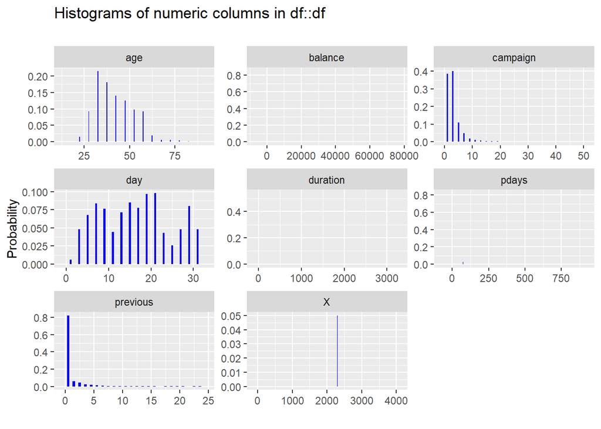

```
## # A tibble: 8 x 10
##   col_name   min     q1 median     mean     q3   max     sd pcnt_na hist
##   <chr>    <int>  <dbl>  <int>    <dbl>  <dbl> <int>  <dbl>   <dbl> <list>
## 1 age         19    33      39   41.2      49     87 1.06e1       0 <tibbl~
## 2 balance  -2082    68     445 1416.     1470  71188 3.02e3       0 <tibbl~
## 3 campaign     1     1       2    2.78      3     50 3.08e0       0 <tibbl~
## 4 day          1     9      16   15.9      21     31 8.21e0       0 <tibbl~
## 5 duration     4   104     184  262.      326.  3025 2.59e2       0 <tibbl~
## 6 pdays       -1    -1      -1   39.4      -1    871 9.95e1       0 <tibbl~
## 7 previous     0     0       0    0.540     0     24 1.65e0       0 <tibbl~
## 8 X            1  1000.   2000 2000      3000.  3999 1.15e3       0 <tibbl~
```

```r
# Summary statistics, numeric variables
inspect_num(df, show_plot = TRUE)
```

Due to the inability to adjust bin width within the `inspect_num` function we will generate plots of `balance`, `duration` and `pdays` separately to get a clearer picture of their distribution.

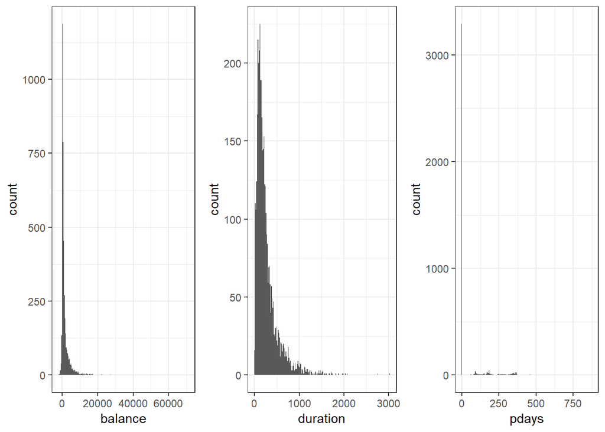

```r
# Histogram of pdays
balancehist <- ggplot(df, aes(balance)) +
    geom_histogram(bins = 200) +
    theme_bw()

# Histogram of duration
durationhist <- ggplot(df, aes(duration)) +
    geom_histogram(bins = 200) +
    theme_bw()

# Histogram of pdays
pdayshist <- ggplot(df, aes(pdays)) +
    geom_histogram(bins = 200) +
    theme_bw()

# Plot formatting
grid.arrange(balancehist, durationhist, pdayshist, ncol=3)
```

Notes:

- All distributions are heavily right skewed
- The vast majority of values in `pdays` appear to be -1 which represents that a client was not contacted in previous campaigns
- It may be prudent to carry out sensitivity analyses to determine the impact of high leverage points or consider log transformations

#### Categorical Variables

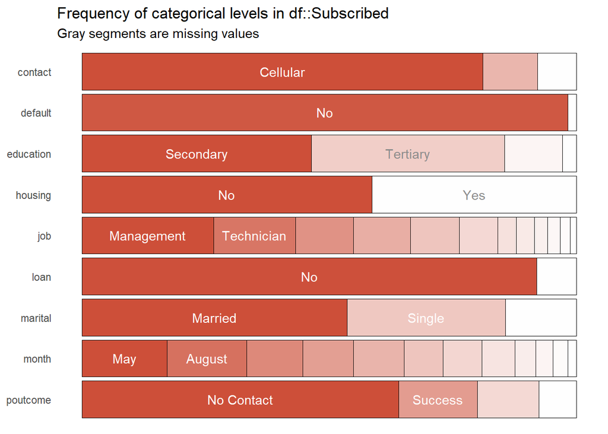

```
## # A tibble: 9 x 5
##   col_name    cnt common     common_pcnt levels
##   <chr>     <int> <chr>            <dbl> <list>
## 1 contact       3 Cellular          81.0 <tibble [3 x 2]>
## 2 default       2 No                98.3 <tibble [2 x 2]>
## 3 education     4 Secondary         46.4 <tibble [4 x 2]>
## 4 housing       2 No                58.6 <tibble [2 x 2]>
## 5 job          12 Management        26.6 <tibble [12 x 2]>
## 6 loan          2 No                91.9 <tibble [2 x 2]>
## 7 marital       3 Married           53.6 <tibble [3 x 2]>
## 8 month        12 May               17.2 <tibble [12 x 2]>
## 9 poutcome      4 No Contact        64.1 <tibble [4 x 2]>
```

```r
# Subset by term deposit subscription (n = 458)
Subscribed <- df %>%
  filter(y == "Yes") %>%
  select(-y)

# Subset by no subscription (n = 3541)
NotSubscribed <- df %>%
  filter(y == "No") %>%
  select(-y)

# Proportion of categorical variables by subscription
inspect_cat(Subscribed, show_plot = TRUE)
```

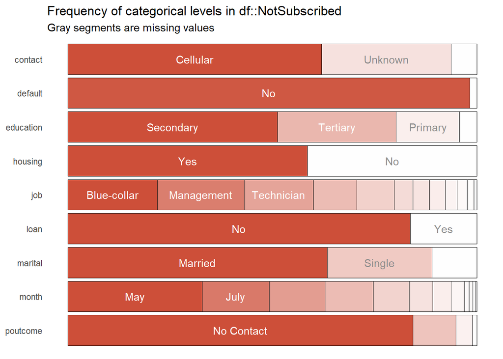

```
## # A tibble: 9 x 5
##   col_name    cnt common      common_pcnt levels
##   <chr>     <int> <chr>             <dbl> <list>
## 1 contact       3 Cellular           62.0 <tibble [3 x 2]>
## 2 default       2 No                 98.3 <tibble [2 x 2]>
## 3 education     4 Secondary          51.3 <tibble [4 x 2]>
## 4 housing       2 Yes                58.5 <tibble [2 x 2]>
## 5 job          12 Blue-collar        21.9 <tibble [12 x 2]>
## 6 loan          2 No                 83.7 <tibble [2 x 2]>
## 7 marital       3 Married            63.4 <tibble [3 x 2]>
## 8 month        12 May                32.8 <tibble [12 x 2]>
## 9 poutcome      4 No Contact         84.4 <tibble [4 x 2]>
```

```r
inspect_cat(NotSubscribed, show_plot = TRUE)
```

It appears that those that subscribed to a new term deposit:

- Were more frequently contacted by mobile phone than those who didn’t subscribe
- Had defaulted on a loan at similar rates to those who didn’t subscribe
- Had a higher level of education on average
- Tended to not have a housing loan

# Inspecting Relationships Between Predictor Variables

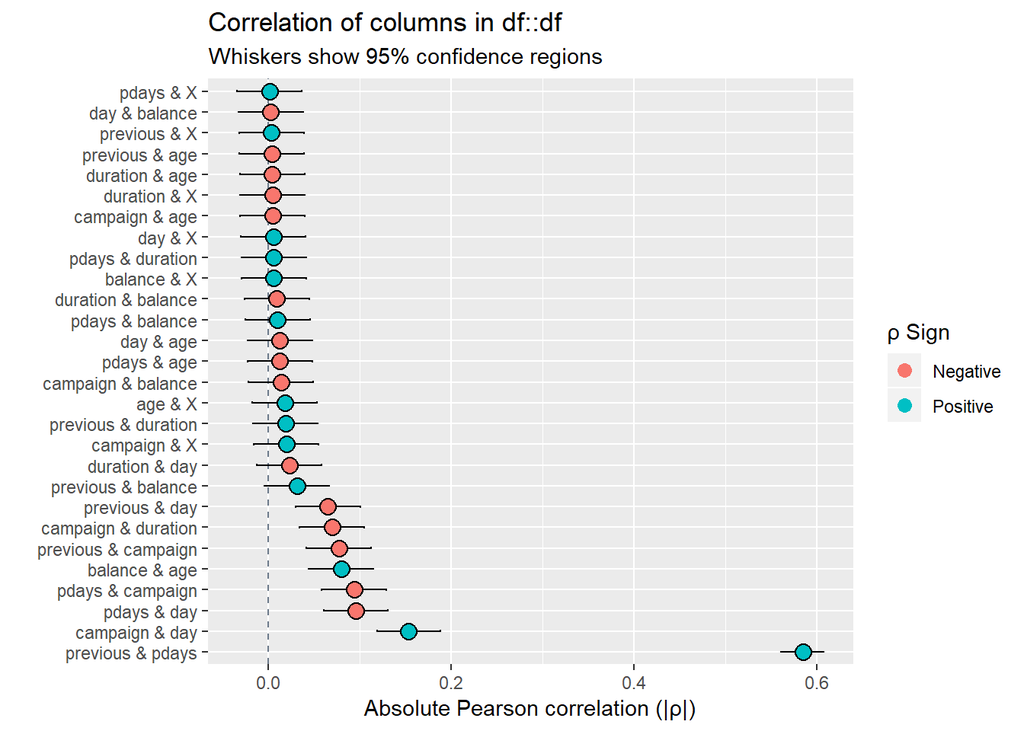

```
## # A tibble: 28 x 6
##    col_1    col_2       corr  p_value    lower   upper
##    <chr>    <chr>      <dbl>    <dbl>    <dbl>   <dbl>
##  1 previous pdays     0.585  0.        0.561    0.608
##  2 campaign day       0.154  1.46e-22  0.119    0.188
##  3 pdays    day      -0.0959 1.25e- 9 -0.131   -0.0606
##  4 pdays    campaign -0.0939 2.68e- 9 -0.129   -0.0587
##  5 balance  age       0.0797 4.57e- 7  0.0443   0.115
##  6 previous campaign -0.0774 9.51e- 7 -0.113   -0.0421
##  7 campaign duration -0.0698 9.96e- 6 -0.105   -0.0344
##  8 previous day      -0.0654 3.52e- 5 -0.101   -0.0300
##  9 previous balance   0.0315 4.64e- 2 -0.00394  0.0669
## 10 duration day      -0.0231 1.44e- 1 -0.0585   0.0123
## # ... with 18 more rows
```

```r
inspect_cor(df, show_plot = TRUE)
```

There is a moderate correlation between `pdays` and `previous` as these appear to represent similar information. The value -1 in `pdays` signifies that a client has not been contacted regarding a term deposit which is the same information given by a zero in `previous`. These values make up the majority of observations in our dataframe so may be a source of multicollinearity. In light of this we will remove `pdays` from the full model.

## Suitability of Predictor Variables

### Duration and Term Deposit Subscribership

There is a moderately strong relationship between call duration and whether a client subscribes to a term deposit. This is likely due to the additional time required for the caller to provide more information if the client shows interest. As call duration is recorded as a result of the interaction and is unknown beforehand it cannot be used as a predictor variable. All of the other variables are known prior through banking records and information from previous advertising campaigns and appear to be suitable for model building.

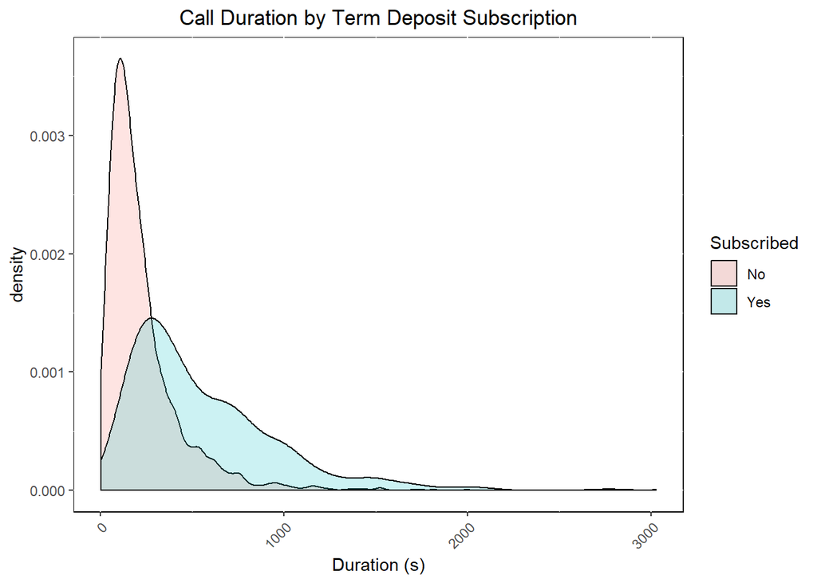

[output not shown]

```r
# Plot duration by y
ggplot(df) +
  geom_density(aes(duration, fill = y),alpha = 0.2) +
  theme(plot.title = element_text(hjust = 0.5),panel.background = element_rect(fill = 'white', color = "black"),axis.text.x = element_text(angle = 45, hjust = 1)) +
  xlab("Duration (s)") +
  ggtitle("Call Duration by Term Deposit Subscription") +
  guides(fill=guide_legend(title="Subscribed"))
```

### Patterns in variables relative to y

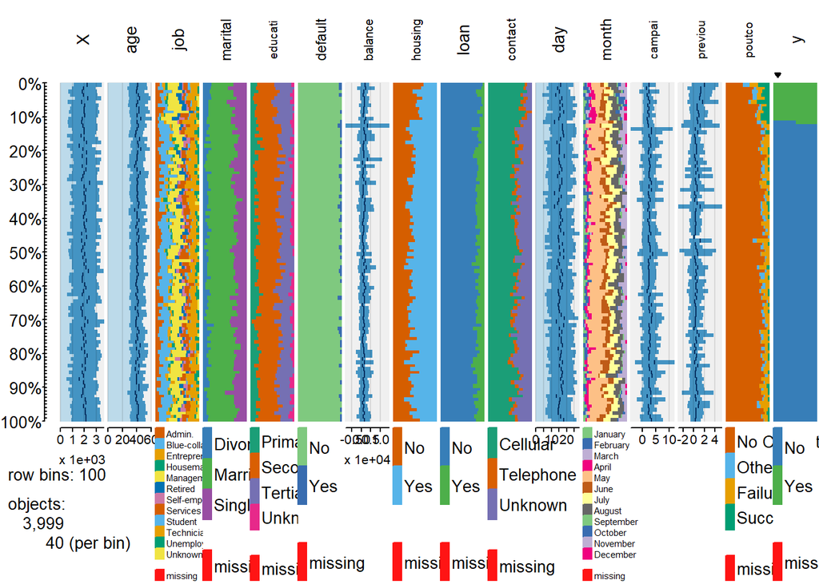

```r
# Plot relationships between variables sorted by y
df %>%
  select(-pdays, -duration) %>%
  tableplot(., sortCol = y)
```

Factors that appear to influence wheather a client subscribes to a term deposit as a result of this marketing campaign include:

- Whether they have an outstanding loan (Housing or personal)
- The method of contact
- Whether they had previously signed up for a term deposit

## Breakdown by Job Type

Management jobs constitute the single largest group at over 21% of all clients contacted.

```r
# Table of profession proportions
df %>%
  group_by(job) %>%
  summarise (n = n()) %>%
  mutate(freq = n / sum(n))
```

```
## # A tibble: 12 x 3
##    job               n    freq
##    <fct>         <int>   <dbl>
##  1 Admin.          430 0.108
##  2 Blue-collar     829 0.207
##  3 Entrepreneur    150 0.0375
##  4 Housemaid        99 0.0248
##  5 Management      871 0.218
##  6 Retired         205 0.0513
##  7 Self-employed   161 0.0403
##  8 Services        360 0.0900
##  9 Student          74 0.0185
## 10 Technician      675 0.169
## 11 Unemployed      112 0.0280
## 12 Unknown          33 0.00825
```

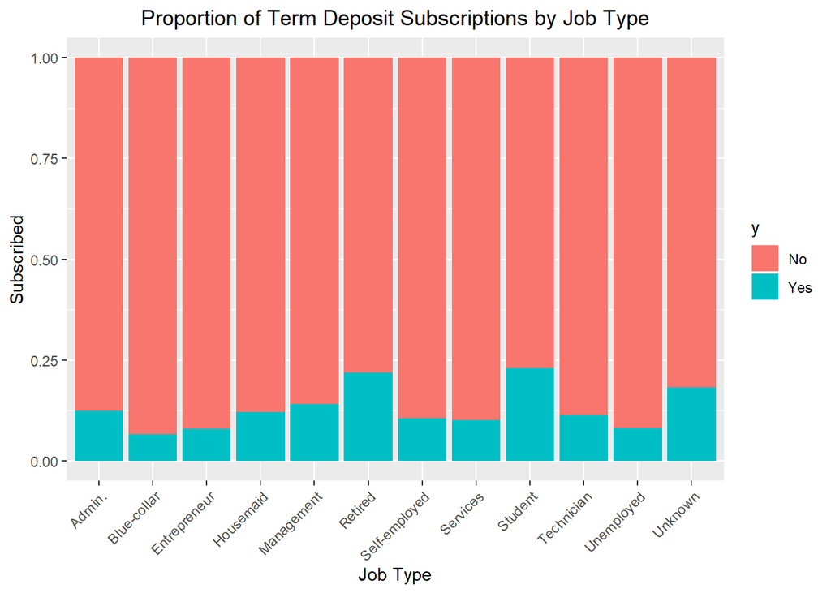

```r
# Plot of profession proportions
df %>%
  group_by(job, y) %>%
  ggplot(.,aes(x = job, fill = y)) +
    geom_bar(position = "fill") +
    xlab("Job Type") +
    ylab("Subscribed") +
    ggtitle("Proportion of Term Deposit Subscriptions by Job Type") +
    theme(plot.title = element_text(hjust = 0.5), axis.text.x = element_text(angle = 45, hjust = 1))
```

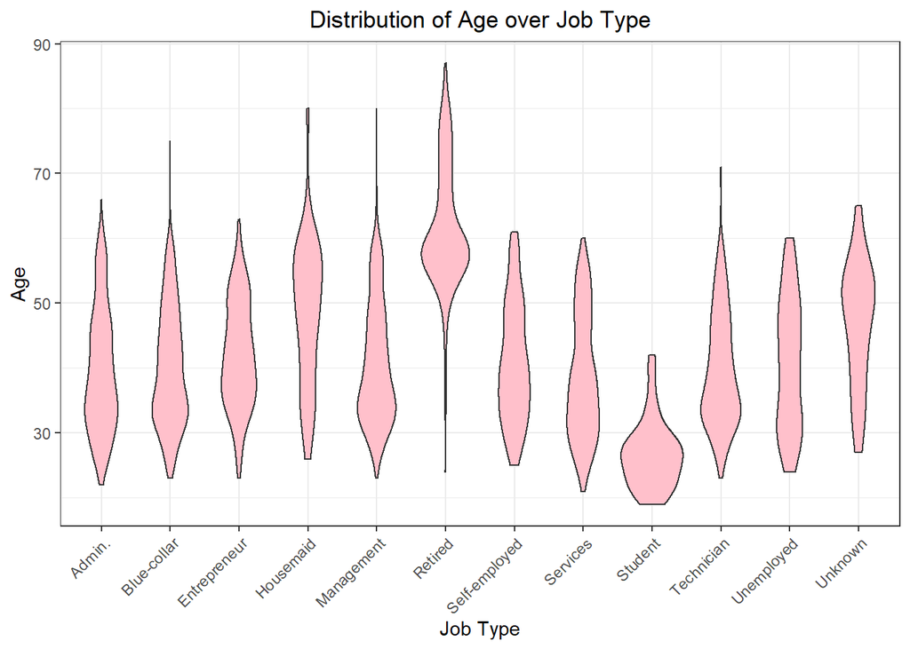

```r
# Violing plot of job by age
ggplot(df, aes(x=job, y=age)) +
  geom_violin(fill = "pink") +
  xlab("Job Type") +
  ylab("Age") +
  ggtitle("Distribution of Age over Job Type") +
  theme_bw() +
  theme(plot.title = element_text(hjust = 0.5), axis.text.x = element_text(angle = 45, hjust = 1))
```

It appears that students and retirees are more likely to apply for a term deposit and the majority of these groups are below 30 and above 50 years old respectively.

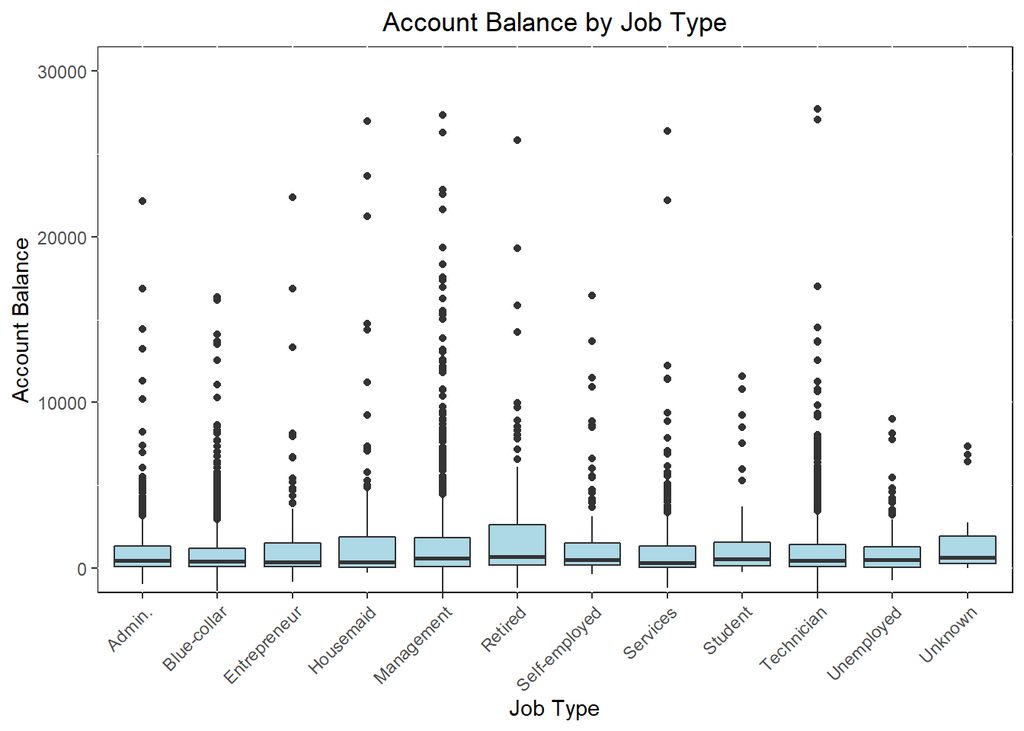

```r
# Plot balance by job
ggplot(df, aes(x=job, y=balance)) +
  geom_boxplot(fill = "light blue") +
  theme(plot.title = element_text(hjust = 0.5),panel.background = element_rect(fill = 'white', color = "black"),axis.text.x = element_text(angle = 45, hjust = 1)) +
  xlab("Job Type") +
  ylab("Account Balance") +
  ggtitle("Account Balance by Job Type") +
  guides(fill=guide_legend(title="Subscribed")) +
  coord_cartesian(ylim = c(0, 30000))
```

Retired people and students have the highest proportion of term deposit subscriptions and they are also our oldest and youngest age groups respectively.

## Breakdown by Age Group

```r
# Create age bands
df <- df %>% mutate(agegroup = as.factor(case_when(age >= 15  & age <= 24 ~ '1',
                                         age >= 25  & age <= 34 ~ '2',
                                         age >= 35  & age <= 44 ~ '3',
                                         age >= 45  & age <= 54 ~ '4',
                                         age >= 55  & age <= 64 ~ '5',
                                         age >= 65 ~ '6')))

# Table of frequency: Age Groups
df %>%
  group_by(agegroup) %>%
  summarise (n = n()) %>%
  mutate(freq = n / sum(n))
```

```
## # A tibble: 6 x 3
##   agegroup     n   freq
##   <fct>    <int>  <dbl>
## 1 1           63 0.0158
## 2 2         1232 0.308
## 3 3         1287 0.322
## 4 4          893 0.223
## 5 5          448 0.112
## 6 6           76 0.0190
```

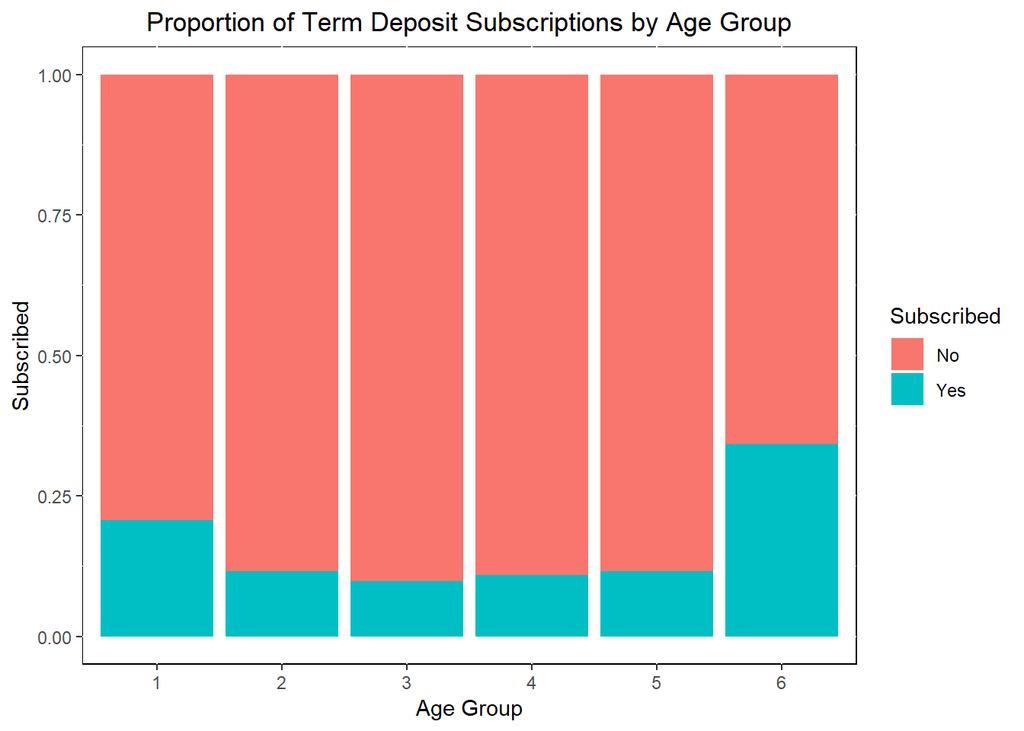

```r
df %>%
  group_by(agegroup, y) %>%
  ggplot(.,aes(x = agegroup, fill = y)) +
    geom_bar(position = "fill") +
    xlab("Age Group") +
    ylab("Subscribed") +
    ggtitle("Proportion of Term Deposit Subscriptions by Age Group") +
    guides(fill=guide_legend(title="Subscribed")) +
    theme(plot.title = element_text(hjust = 0.5),panel.background = element_rect(fill = 'white', color = "black"))
```

We see that over 62% of all clients contacted are between the ages of 25 and 44. The proportion of clients that subscribed to a new term deposit is however much higher in the Under 25 and Over 64 age groups. These groups account for less than 4% of total campaign contacts so targetting customers in this age range may yield higher subscriptions if this proportion holds.

### Education

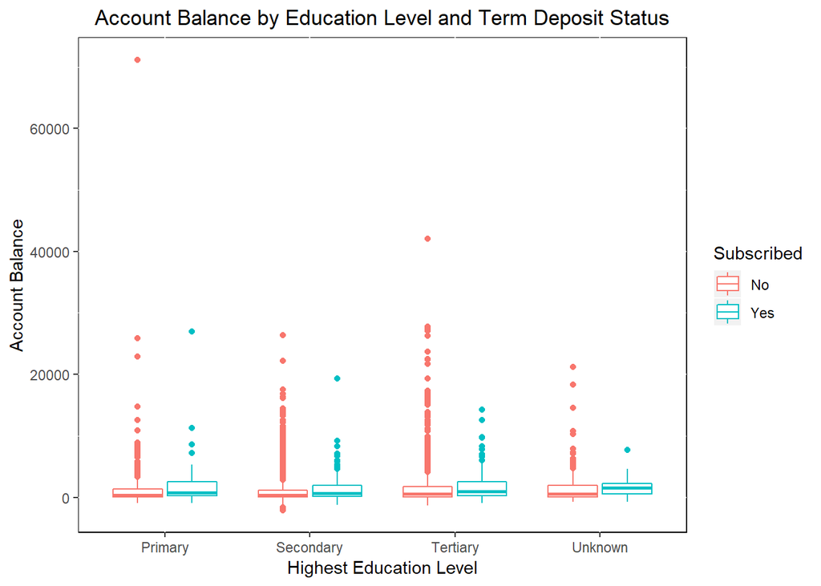

```r
#
ggplot(df, aes(education, balance, color = y)) +
  geom_boxplot() +
  xlab("Highest Education Level") +
  ylab("Account Balance") +
  ggtitle("Account Balance by Education Level and Term Deposit Status") +
  guides(color =guide_legend(title="Subscribed")) +
  theme(plot.title = element_text(hjust = 0.5),panel.background = element_rect(fill = 'white', color = "black"))
```